# Nike Sales Data 2020-2021

Jamie Kerlin

2024-07-30

# 1 Overview

## 1.1 Purpose

The purpose of this document is to clean and analyze the Nike Sales Dataset 2020-2021.

## 1.2 Data Citation

This is a test dataset downloaded from Kaggle on 2024-07-30 https://www.kaggle.com/datasets/pavankota2020/nike-sales-dataset?resource=download

# 2 Setup

## 2.1 Load libraries

```r
package_names <- c("tidyverse", "here", "janitor", "vtable", "ggimage", "lubridate")

for(x in package_names){
  if(!x %in% rownames(installed.packages())) install.packages(x)
}

library(tidyverse)
library(here)
library(janitor)
library(lubridate)
library(vtable)
library(ggimage)
```

## 2.2 Load data

```r
data <- read_csv(here("Nike_Sales_Data",
                      "Data",
                      "Data_Raw",
                      "nike_data.csv"))
```

# 3 Data exploration and cleaning

## 3.1 Clean names

Change the column names to clean names using janitor package.

```r
data <- data %>%
  clean_names()
```

## 3.2 Explore data

First, check for basics such as missing values, the number of distinct values in each column, and the data class for each of the columns.

```r
# 9360 rows, 9 columns

# Check for any NAs
nas <- data %>%
  filter(!complete.cases(.))

# How many distinct values are in each of the columns?
data %>%
  map_dbl(n_distinct)
```

```
##   invoice_date        product         region       retailer   sales_method
##            724              6              5              6              3
##          state price_per_unit    total_sales     units_sold
##             48             94            550             89
```

```r
# What classes of data are in the dataset?
vtable(data)
```

data

| Name | Class | Values |
| --- | --- | --- |
| invoice_date | character |  |
| product | character |  |
| region | character |  |
| retailer | character |  |
| sales_method | character |  |
| state | character |  |
| price_per_unit | numeric | Num: 7 to 110 |
| total_sales | numeric | Num: 0 to 8250 |
| units_sold | numeric | Num: 0 to 128 |

```r
# see if duplicated rows for all categories
dupes <- data %>%
  select(where(is.character)) %>%
  get_dupes()


# look at those duplicated rows- there are multiple rows for categories but no unique identifier for the products
# so the duplicates are OK
get_dupes <- left_join(dupes, data)
```

## 3.3 Descriptives

Next, I will look at descriptives of those column values

What are the frequencies of the values in the columns?

```r
sumtable(data)
```

Summary Statistics

| Variable | N | Mean | Std. Dev. | Min | Pctl. 25 | Pctl. 75 | Max |
| --- | --- | --- | --- | --- | --- | --- | --- |
| product | 9360 |  |  |  |  |  |  |
| … Men’s Apparel | 1560 | 16.7% |  |  |  |  |  |
| … Men’s Athletic Footwear | 1560 | 16.7% |  |  |  |  |  |
| … Men’s Street Footwear | 1560 | 16.7% |  |  |  |  |  |
| … Women’s Apparel | 1560 | 16.7% |  |  |  |  |  |
| … Women’s Athletic Footwear | 1560 | 16.7% |  |  |  |  |  |
| … Women’s Street Footwear | 1560 | 16.7% |  |  |  |  |  |
| region | 9360 |  |  |  |  |  |  |
| … Midwest | 1872 | 20% |  |  |  |  |  |
| … Northeast | 2376 | 25.4% |  |  |  |  |  |
| … South | 1728 | 18.5% |  |  |  |  |  |
| … Southeast | 1224 | 13.1% |  |  |  |  |  |
| … West | 2160 | 23.1% |  |  |  |  |  |
| retailer | 9360 |  |  |  |  |  |  |
| … Amazon | 823 | 8.8% |  |  |  |  |  |
| … Foot Locker | 2545 | 27.2% |  |  |  |  |  |
| … Kohl’s | 1030 | 11% |  |  |  |  |  |
| … Sports Direct | 2006 | 21.4% |  |  |  |  |  |
| … Walmart | 582 | 6.2% |  |  |  |  |  |
| … West Gear | 2374 | 25.4% |  |  |  |  |  |
| sales_method | 9360 |  |  |  |  |  |  |
| … In-store | 1740 | 18.6% |  |  |  |  |  |
| … Online | 4745 | 50.7% |  |  |  |  |  |
| … Outlet | 2875 | 30.7% |  |  |  |  |  |
| price_per_unit | 9360 | 44.739 | 14.506 | 7 | 35 | 55 | 110 |
| total_sales | 9360 | 921.931 | 1413.843 | 0 | 42 | 1463 | 8250 |
| units_sold | 9360 | 25.853 | 21.592 | 0 | 11 | 35 | 128 |

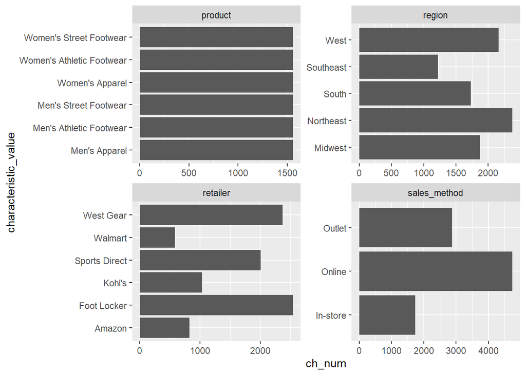

```r
data_gg <- data %>%
  pivot_longer(cols = product:sales_method,
               names_to = "characteristic",
               values_to = "characteristic_value") %>%
  group_by(characteristic, characteristic_value) %>%
  summarise(ch_num = n())


ggplot(data_gg, mapping = aes(x = characteristic_value, y = ch_num)) +
  geom_col() +
  coord_flip() +
  facet_wrap(~characteristic, scales = "free")
```

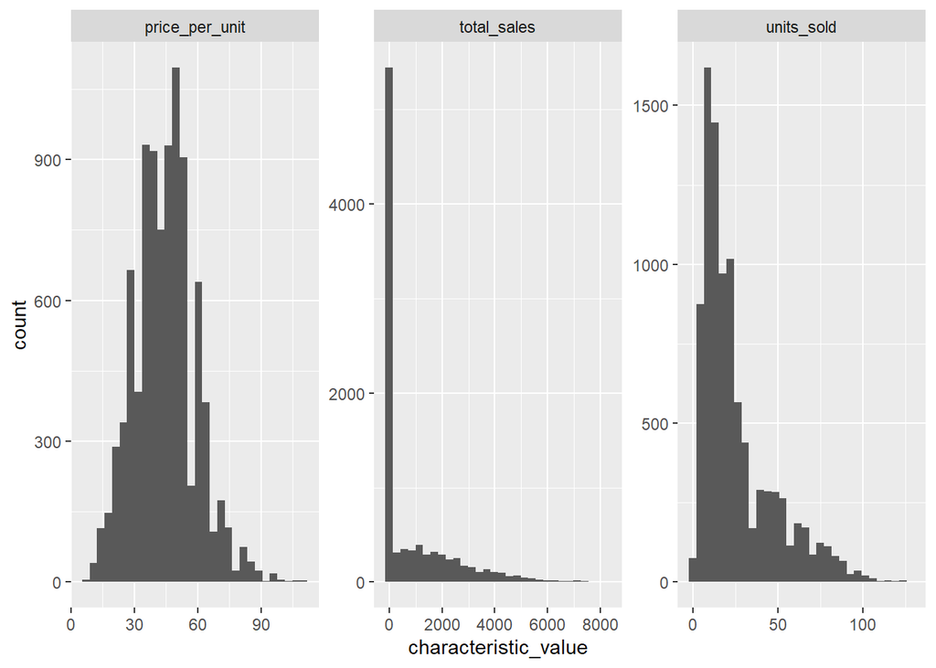

```r
data_gg_num <- data %>%
  pivot_longer(cols = price_per_unit:units_sold,
               names_to = "characteristic",
               values_to = "characteristic_value")


ggplot(data_gg_num, mapping = aes(x = characteristic_value)) +
  geom_histogram() +
  facet_wrap(~characteristic, scales = "free")
```

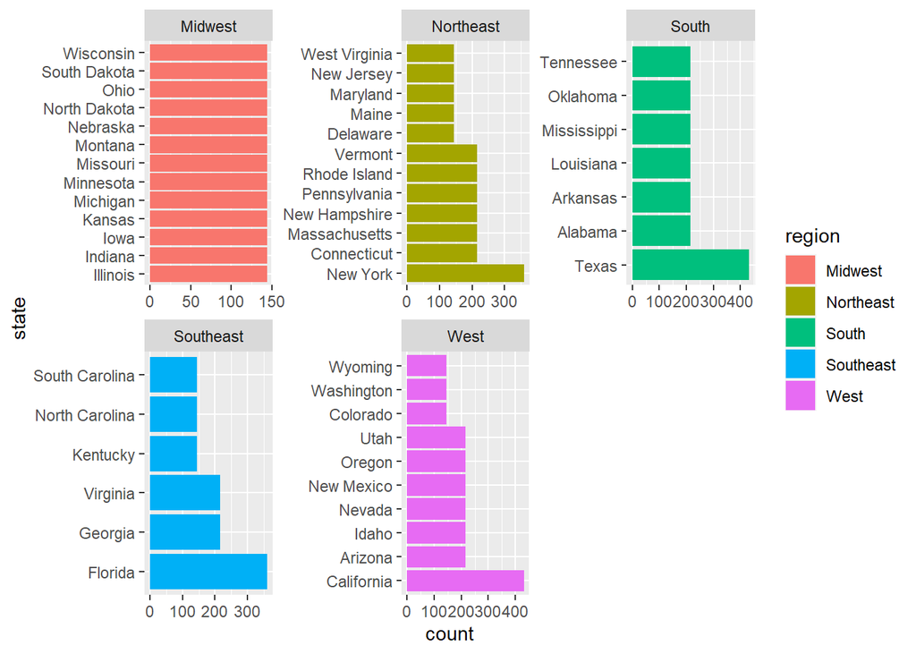

```r
data %>%
  mutate(state = fct_infreq(state)) %>%
  ggplot(mapping = aes(x = state, fill = region)) +
    geom_bar() +
    coord_flip() +
    facet_wrap(~region, scales = "free")
```

Check invoice date

I want to make sure the date format is consistent in the invoice date column

```r
date_test <- data %>%
  mutate(year = str_sub(invoice_date, 7, 10),
         month = str_sub(invoice_date, 4, 5),
         day = str_sub(invoice_date, 1, 2))

date_test %>% count(year)
```

```
## # A tibble: 2 × 2
##   year      n
##   <chr> <int>
## 1 2020   1302
## 2 2021   8058
```

```r
date_test %>% count(month)
```

```
## # A tibble: 12 × 2
##    month     n
##    <chr> <int>
##  1 01      835
##  2 02      746
##  3 03      778
##  4 04      817
##  5 05      796
##  6 06      705
##  7 07      750
##  8 08      829
##  9 09      800
## 10 10      790
## 11 11      771
## 12 12      743
```

```r
date_test %>% count(day)
```

```
## # A tibble: 31 × 2
##    day       n
##    <chr> <int>
##  1 01       97
##  2 02      193
##  3 03      310
##  4 04      285
##  5 05      337
##  6 06      421
##  7 07      270
##  8 08      306
##  9 09      336
## 10 10      527
## # … with 21 more rows
```

```r
# ok, date formats are correct- use lubridate on the column to get final consistent format
data$invoice_date <- lubridate::dmy(data$invoice_date)
```

Create a dataset to compare sales by categories

```r
data_sales <- data %>%
  pivot_longer(cols = product:state,
               names_to = "cat_char",
               values_to = "cat_value") %>%
  pivot_longer(cols = price_per_unit:units_sold,
               names_to = "num_char",
               values_to = "num_value") %>%
  group_by(cat_char, cat_value, num_char) %>%
  summarise(mean_num_value = mean(num_value),
            total_num_value = sum(num_value)) %>%
  filter(cat_char != "state") %>%
  ungroup() %>%
  group_by(cat_char) %>%
  nest()
```

Compare average daily sales

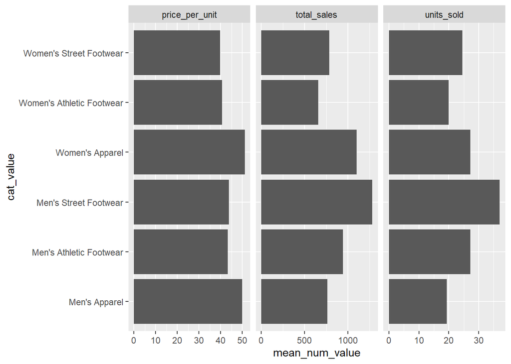

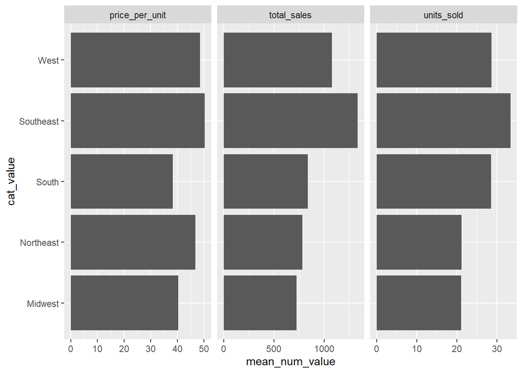

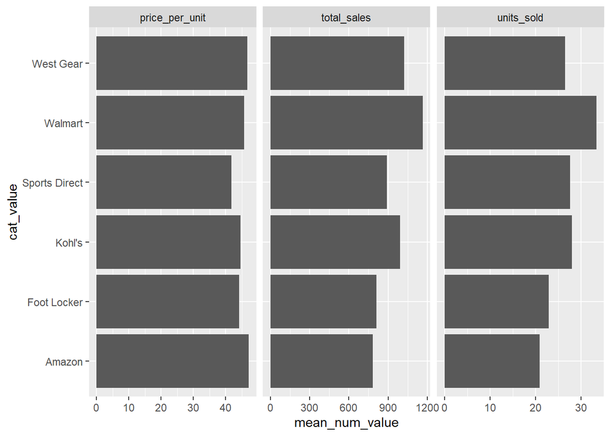

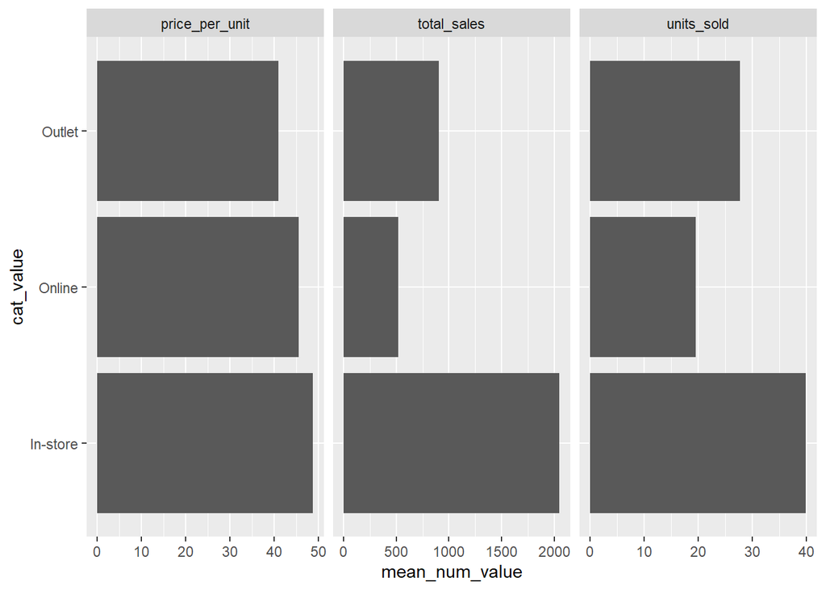

```r
output <- list()

for(y in 1:4){
plot <- data_sales %>%
  pluck("data", y) %>%
  ggplot(mapping = aes(x = cat_value, y = mean_num_value)) +
    geom_col() +
    coord_flip() +
    facet_wrap(~num_char, ncol = 3, scales = "free_x")

output[[y]] <- plot
}

print(output)
```

On average per day:  
- Women and men’s apparel is more expensive than footwear  
- Women’s apparel and men’s street footwear sells the most units, women’s athletic footwear sells the least  
- Price per unit is lower in the south and midwest  
- Most units sold in the west, southeast, and south  
- Price per unit between retailers not very much  
- Walmart sells the most units, Amazon sells the least  
- Outlets have lower price per units  
- Most sales from in-person

Compare total sales over 2 years

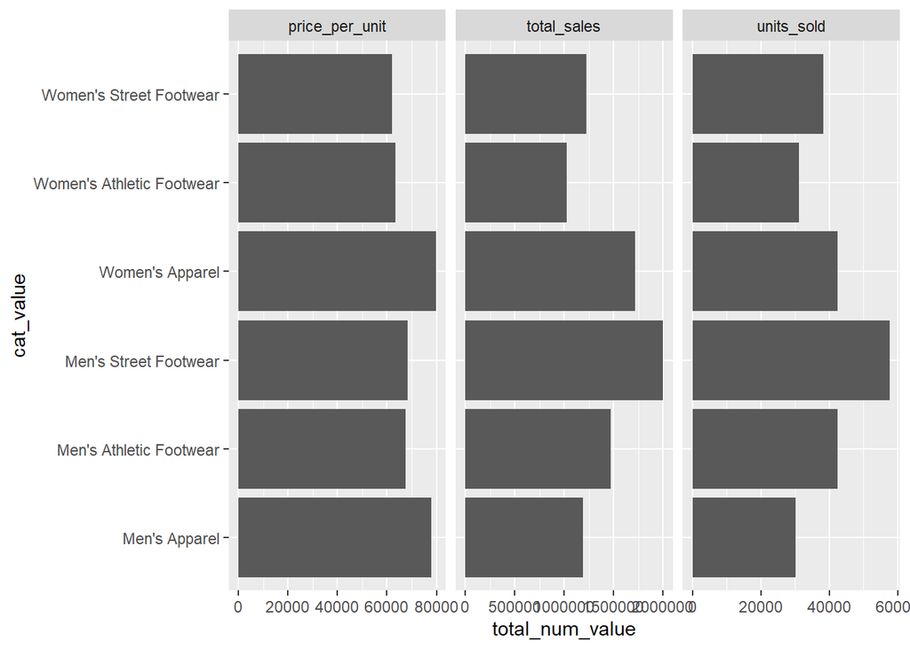

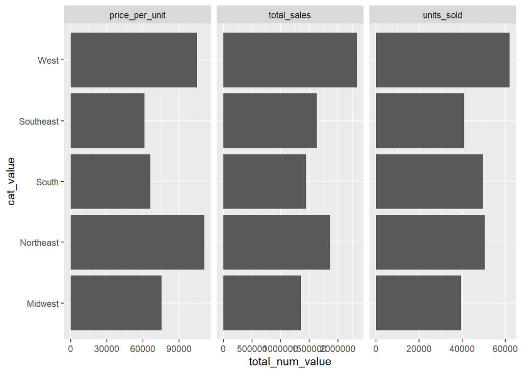

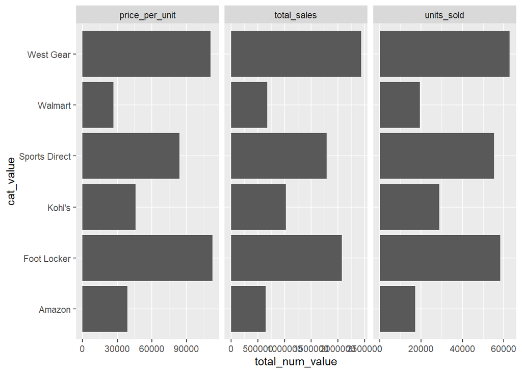

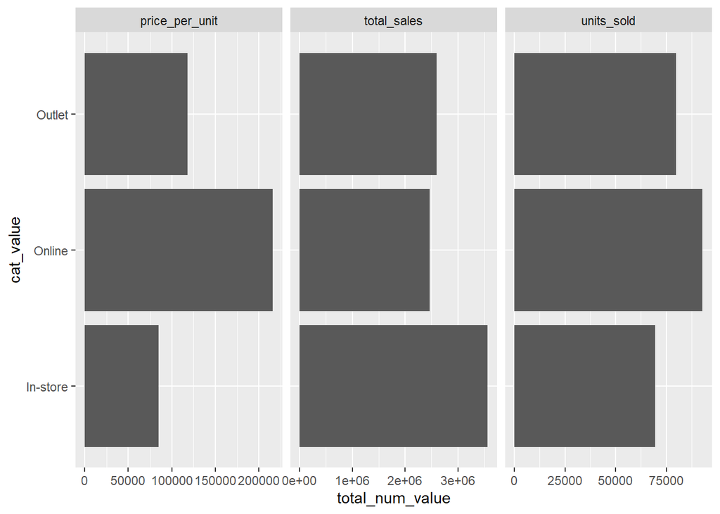

```r
output <- list()

for(y in 1:4){
plot <- data_sales %>%
  pluck("data", y) %>%
  ggplot(mapping = aes(x = cat_value, y = total_num_value)) +
    geom_col() +
    coord_flip() +
    facet_wrap(~num_char, ncol = 3, scales = "free_x")

output[[y]] <- plot
}

print(output)
```

Total throughout the two years: - Women and men’s apparel is more expensive than footwear  
- Women’s apparel and men’s street footwear sells the most units, followed closely by men’s athletic footwear - Women’s athletic footwear and men’s apparel sell the fewest units - Price per unit is way higher in west and northeast - Most units sold in the west, northeast, and south  
- Price per unit very different but because more units sold at some places - Most units sold at West Gear, Foot Locker, and Sports Direct - Most units sold online, fewest in-store

What do the sales look like throughout the two years?

Make a dataset to look at sales by year, quarter, month

```r
data_time <- data %>%
  mutate(year = year(invoice_date),
         quarter = quarter(invoice_date),
         month = month(invoice_date)) %>%
  select(!product:state) %>%
  pivot_longer(cols = year:month,
               names_to = "date_char",
               values_to = "date_value") %>%
  pivot_longer(cols = price_per_unit:units_sold,
               names_to = "num_char",
               values_to = "num_value") %>%
  group_by(date_char, date_value, num_char) %>%
  summarise(num_value = if_else(num_char == "price_per_unit", mean(num_value), sum(num_value))) %>%
  unique() %>%
  ungroup() %>%
  group_by(date_char) %>%
  nest()
```

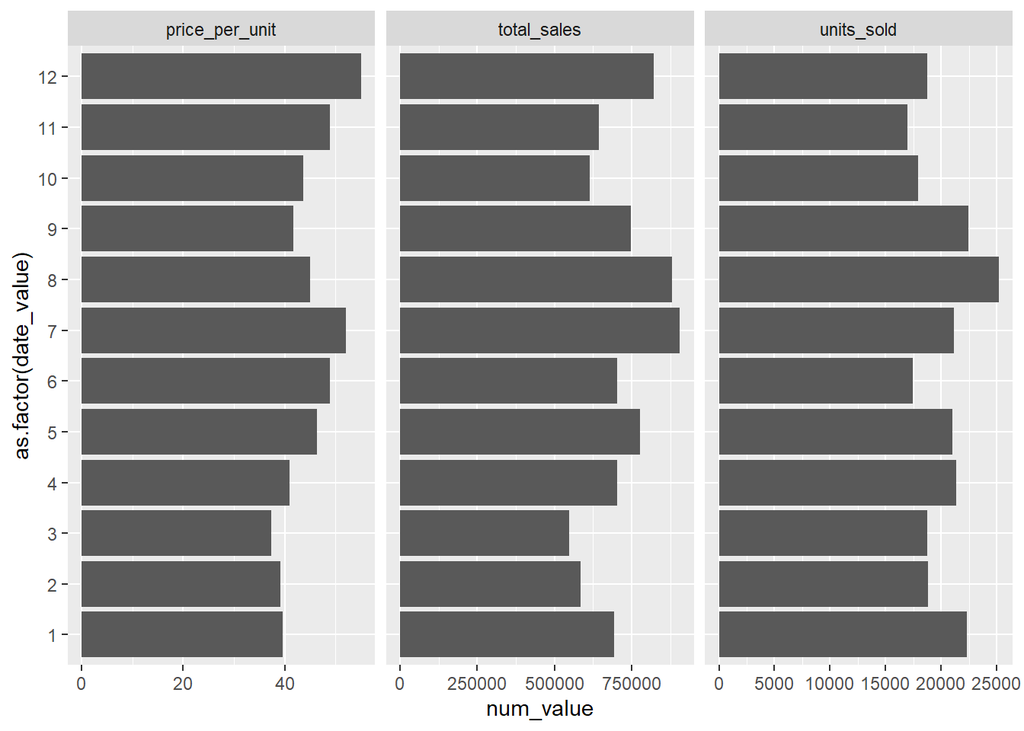

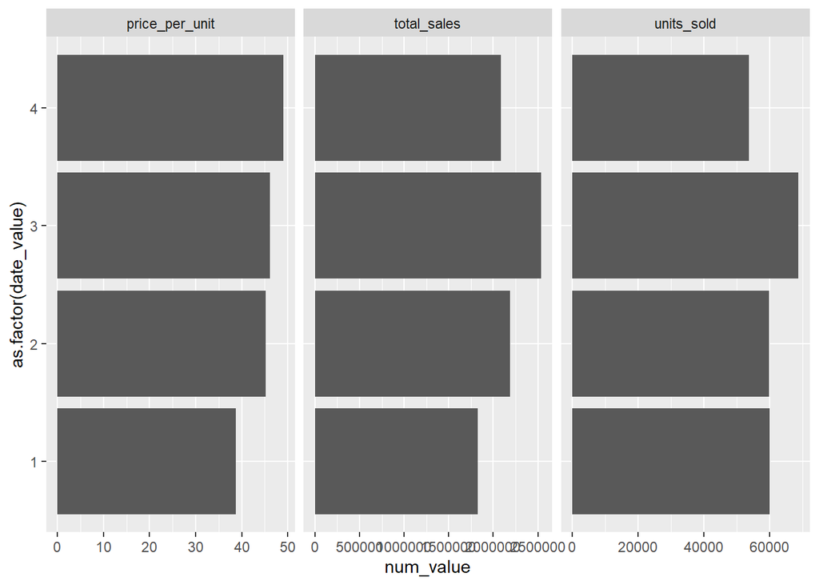

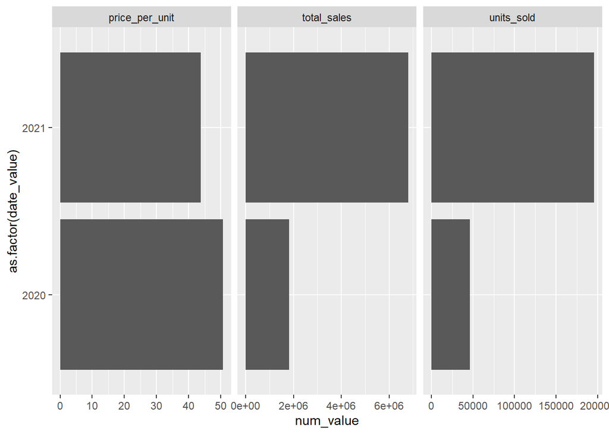

```r
output <- list()

for(y in 1:3){
plot <- data_time %>%
  pluck("data", y) %>%
  ggplot(mapping = aes(x = as.factor(date_value), y = num_value)) +
    geom_col() +
    coord_flip() +
    facet_wrap(~num_char, ncol = 3, scales = "free_x")

output[[y]] <- plot
}

print(output)
```

Over time:  
- More expensive things (inc mean price per unit) sold in December and July  
- Most units sold in January, August and September  
- More expensive items sold in 2020 but more items in total sold in 2021